# Polyploidy Undergraduate Research Experience (PURE) Virtual Workshop

Rosana Zenil-Ferguson & Pamela Rueda-Cediel

2026-06-29

# Introduction to visualization and statistics

This module in the PURE workshop introduces students some basic tools in R for exploring, summarizing, visualizing, and analyzing biological datasets related to polyploidy.

Rmarkdown is a tool that help us keep track of our analyses resulting in reproducible analyses.

For this workshop we will use two different data sets:

1. **Flowering traits**  
   Porturas, L. D., Anneberg, T. J., Curé, A. E., Wang, S., Althoff, D. M., & Segraves, K. A. (2019). *A meta-analysis of whole genome duplication and the effects on flowering traits in plants*. *American Journal of Botany, 106*(3), 469–476. [link](https://polyploidybii.github.io/pure_2026/slides/porturas_2019_floweringploidy.pdf)

   File name: `data_porturas.csv`
2. **Cell and body size of Daphnia**  
   Pecl, I., Blier, P. U., & Dufresne, F. (2025). *Polyploidy confers better cold tolerance in Daphnia*. *Oikos, 2025*, e10991.  
   [link](https://polyploidybii.github.io/pure_2026/slides/oikos_pecl_daphnia_2024.pdf)

   File name: `daphnia_cellsize.csv`

# The basics

## Initial setup

In this section we prepare the R session for the workshop. Hashtags like the one above produce sections and subsections. As you will see next, hashtags inside backward accents help us commenting on code, and do not produce document sections.

A cheatsheet for Rmarkdown files is [here](https://rmarkdown.rstudio.com/lesson-15.HTML)

```r
# Backward accents open code to be run by the computer

# Hashtags here are for commenting in R. Useful for notes and to prevent code from running.

# In a local computer we install packages as
# install.packages("ggplot2")
# In our workshop everything is installed for you.

# Libraries have functions to manipulate data and visualize it

library(dplyr)      # Data manipulation: filter(), mutate(), summarise(), count(), %>%
library(ggplot2)    # Data visualization: ggplot(), geom_bar(), geom_boxplot(), geom_point()
library(forcats)    # Factor handling: fct_infreq() to order categories by frequency
library(tidyr)      # Data reshaping: pivot_longer() to reorganize data

# If you want to use a function without loading the whole package:
# package_name::function_name()
# Example:
# scales::percent_format()
```

## Finding and printing our output

So we are all seeing the same please click in the gear icon above and select **Chunk Output in Console**

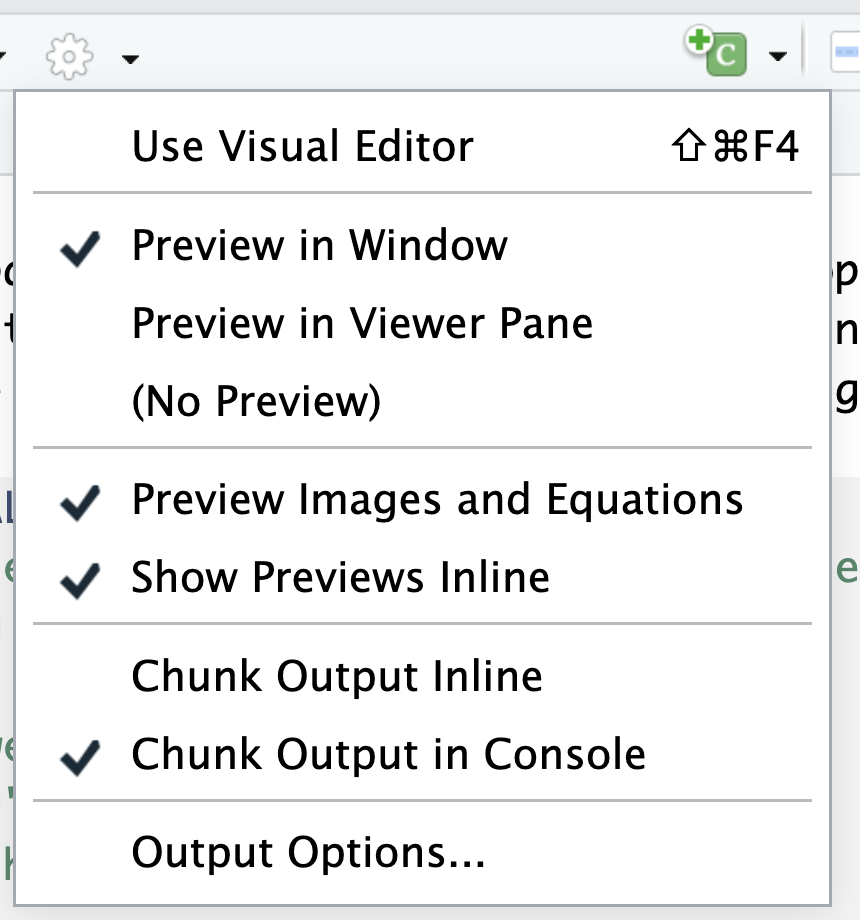

# 1. Flowering traits:

## 1.1 Load and inspect the data

In this first section we import the flowering traits dataset and inspect its general structure. This is always a useful first step before beginning any analysis because it helps us understand the variables, data types, and overall contents of the dataset. The code here generates a computer object called `flowering_traits` that contains all of of your data. This object will be manipulated by different functions (or actions) that are always written as `something()`.

Let’s try our first steps at handling data

1. **Important make sure you change eval=TRUE to create the final document**
2. **Wherever you see a question mark ?, you have to fill in some information**

```r
# Read the dataset
flowering_traits = read.csv("data_porturas.csv")
#flowering_traits is now an object that we can manipulate in our computer

# For example we can print the first rows and observing them
head(flowering_traits) ## Looking at the first 6 rows of data

# What should you put in this next function and what is it doing?
tail(?) ##

#Notice that functions like tail() modify and extract information from objects

colnames(?) ## Looking at the headings of my data


summary(?) ## Getting a summary of my data

# What happens if you use this instruction?
View(?)
```

Let’s talk more about the data…

## 1.2 Summarize the trait variable

Here we summarize the variable trait. We will inspect the unique values, count how many different traits exist, calculate frequencies, proportions, and percentages, and organize the results into summary tables. What we are doing here is that we are “digging” deep into the object, and to accomplish it we need to use a new symbol `$`

### Using base R

**Don’t forget about `eval=TRUE`**

```r
name_traits = unique(flowering_traits$trait)
# What is this function unique() generating?

#How do we know how many traits?
length(?)

# How many observations per trait?
freq = table(flowering_traits$trait)
freq

# Organizing data to see it better using package dplyr
# This is an example using an instruction called pipes %>%

summary_table_sorted = flowering_traits %>%
  count(trait, sort = TRUE) %>%
  mutate(prop = n / sum(n),
         pct = round(prop * 100, 2)
         )
head(?)
View(?)
```

## 1.3 Visualizing trait frequencies

### Plotting with ggplot2

The package `ggplot2` creates easy to manipulate plots and allows us to customize our visualizations. This is the reason why most scientist use it today for communicating science.

Let’s do a barplot investigating how many times a trait is present in our dataset. This is the most basic plot we can do with the `ggplot2` library.

```r
ggplot(flowering_traits, aes(x = trait)) +
  geom_bar()
```

Let’s look at the structure here for a second: 1. There is a function `ggplot(flowering_traits, aes(x=trait))` so `ggplot()` receives first our dataset `flowering_traits`. 2. There is a function within there called `aes(x=trait)` aes stands for aesthetics, or “the looks” of the plot. What we are indicating here is on the x axis you are going to put the column of the dataset called trait. Click on the dataset again to see the column trait. 3. The function `geom_bar()` creates the barplot from the dataset with the aesthetics you indicated earlier!

But still looks ugly, we can’t read a thing. Let’s go to the next step and make it look better

```r
ggplot(flowering_traits, aes(x = trait)) +
  geom_bar() +
  labs(title = "Trait frequency",
       x = "Trait",
       y = "Number of times in dataset") +
  theme_minimal() # comment this out to appreciate the difference in the plot
```

4. What does the function `labs()` did?

This plot is still ugly, let’s go to the next step

```r
ggplot(flowering_traits, aes(x = trait)) +
  geom_bar()+
  labs(title = "Trait frequency",
       x = "Trait",
       y = "Number of times in dataset") +
  theme_minimal() +
  theme(axis.text.x = element_text(angle = 45, hjust = 1),
  panel.grid = element_blank() # Removes grid lines, comment this out
)
```

5. Check out the power of `theme()`, what did it do?
6. Which is the most common trait measured in our dataset?

The function `geom_bar()` counts how many times each trait appears in the data.

The appearance of the graph be change with `theme_minimal()`, `theme_classic()` and `theme_bw()` Using `theme()` you adjust title, axis text,font size, label rotation, legend position, background, grid lines, borders, margins, spacing between elements

### Geeting fancier with ggplot2 sorted barplots

Let’s try the same plot now but prettier. We will change three things to our plot before

- In the function we tell our aesthetics to do this `aes(fct_infreq(trait))` which means, reorganize the vars from the trait that has the most common in our dataset to the least common of them.
- In the function `aes(x = fct_infreq(trait), fill = trait)` we add color to the trait adding `fill=trait` to the plot
- In the function geom_bar(fill = **color**) we select which color we want

```r
ggplot(flowering_traits,
       aes(x = fct_infreq(trait), fill = trait)) +
       geom_bar(fill="blue") +
       labs(title = "Trait frequency", x = "Trait", y = "Number of times in dataset") +
       theme_minimal() +
       theme(axis.text.x = element_text(size =5 ,angle = 45, hjust = 1),
       legend.title = element_text(size = 8),
       legend.text = element_text(size = 4),
       legend.key.size = unit(0.4, "cm") # Legend size
       )
```

### Life is better with more colors

What changed here?- Please explain

```r
ggplot(flowering_traits, aes(x = fct_infreq(trait), fill = trait)) +
       geom_bar() +
       labs(title = "Trait frequency", x = "Trait", y = "Number of times in dataset") +
       theme_minimal() +
       theme(axis.text.x = element_text(size =5 ,angle = 45, hjust = 1),
       legend.title = element_text(size = 8),
       legend.text = element_text(size = 4),
       legend.key.size = unit(0.4, "cm"), # Legend size
       legend.position = "none" # what does this do? what other options could we use?
       )
```

## 1.4 Exploring one measurement: Flower diameter

Now we focus on the effect of polyploidy in flower diameter becaue we observe that flowers have been studied the most in this dataset. We chose diameter for the same reason, we have the most amount of data.

We first subset the data to keep only rows where the trait is “flower”, and then inspect which flower attributes were measured.

To explore a subset of the data we are using package `dplyr` and a tool called pipes `%>%` that help us filter data.

```r
head(flowering_traits)

flower_ploidy= flowering_traits %>%
  filter(trait=="flower" & attribute=="diameter" & base_ploidy=="2x")
head(flower_ploidy)

# Make sure you comment here what this pipe instruction is doing
```

## 1.5 Boxplots of flower diameter by ploidy

To compare before and after values after inducing polyploidy, we first reshape the data into long format. The function pivot_longer() takes the two diameter columns and stacks them into one column, while creating a second column indicating whether the value comes from the before or after measurement. This part of the code allows us to input the data the way ggplot undertands it.

```r
flower_diameter_Bxplot = flower_ploidy %>%
  select(mean_before, mean_after) %>%
  pivot_longer(
    cols = c(mean_before, mean_after),
    names_to = "time",
    values_to = "mean_diameter"
  ) %>%
  mutate(
    ploidy = recode_values(time,
                         "mean_before" ~ "2x",
                         "mean_after"  ~ "4x")
  )

head(flower_diameter_Bxplot)
```

Now let’s follow the same logic we had for barplots but now applied to boxplots

```r
ggplot(flower_diameter_Bxplot, aes(x =ploidy, y = mean_diameter, fill = ploidy)) +
  geom_boxplot()
```

This looks good enough but not great, just as we did with barplots we can customize a ton! FOr example, we put a little white dot indicating the average of mean diameter. Check other changes, why is this plot better?

```r
ggplot(flower_diameter_Bxplot, aes(x =ploidy, y = mean_diameter, fill = ploidy)) +
  geom_boxplot(position = position_dodge(width = 0.8)) +
  stat_summary(
    fun = mean,
    geom = "point",
    aes(group = time),
    shape = 23,
    size = 3,
    fill = "white",
    color = "black",
    position = position_dodge(width = 0.8)
  ) +
  scale_fill_manual(values = c("2x" = "blue", "4x" = "red")) +
  labs(
    x = "Base ploidy",
    y = "Mean diameter (cm)",
    fill = NULL
  ) +
  theme_minimal()
```

Optional- Try new colors for your box and whisker plots!

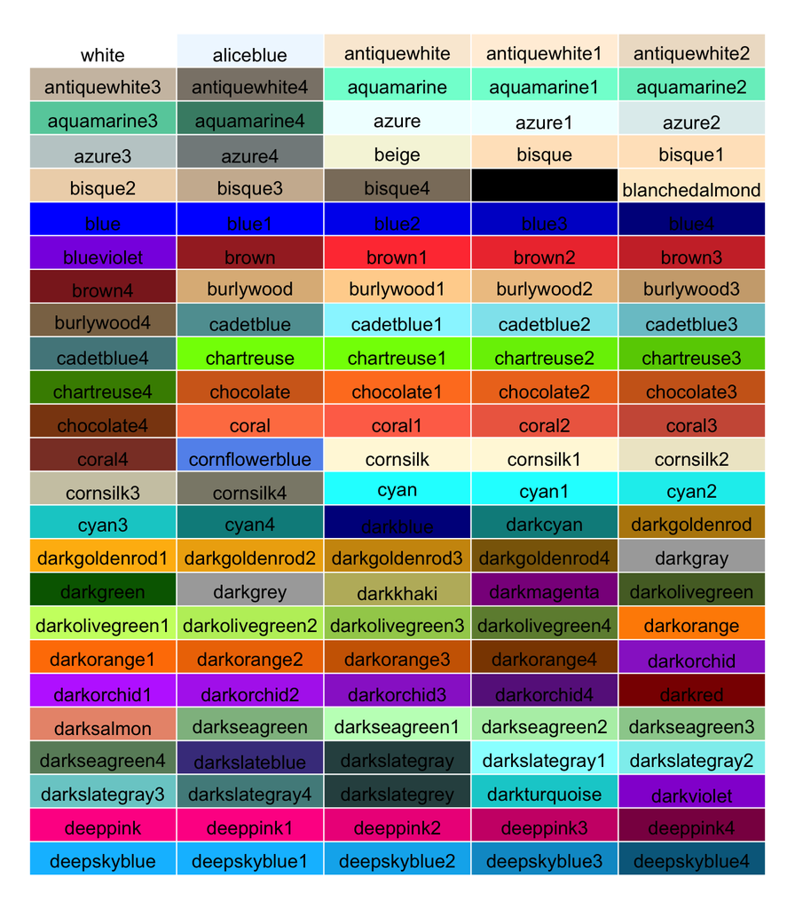

## 1.6 Interpretation of boxplots

The most important part is not only plotting but interpreting these plots. Tell us about the five-point summary

```r
flower_diameter_Bxplot %>%
  group_by(ploidy) %>%
  summarise(
    min = min(mean_diameter, na.rm = TRUE),
    Q1 = quantile(mean_diameter, 0.25, na.rm = TRUE),
    median = median(mean_diameter, na.rm = TRUE),
    Q3 = quantile(mean_diameter, 0.75, na.rm = TRUE),
    max = max(mean_diameter, na.rm = TRUE),
    .groups = "drop"
  )
```

1. Percentiles before and after polyploidy
2. Spread (Calculate the interquartile range)
3. Outliers

## 1.7 (Optional) Formal hypothesis testing

Let’s make a formal t-test to compare the diameter averages before and after the ploidy change.

Our null hypothesis H0 tests if the average diameter before and after inducing polyploidy are equal. If we reject the hypothesis that means they are different, and if we fail to reject this means we cannot claim they are different (but we don’t know if they are equal for sure).

```r
head(flower_ploidy)

t_test = t.test(
  flower_ploidy$mean_after,
  flower_ploidy$mean_before,
  paired = FALSE
   )
t_test
## To extract the statistics
p_value  = t_test$p.value      # Extracts the p-value
p_value
```

How do we interpret a p-value? [Statement by the American Statistical Association](https://www.amstat.org/asa/files/pdfs/p-valuestatement.pdf)

## 1.8 Learning more about ggplot2

There are so many cool resources for ggplot2!

1. [Cheatsheet](https://rstudio.github.io/cheatsheets/data-visualization.pdf)
2. [R for data science](https://r4ds.hadley.nz/data-visualize)
3. [STHDA small blogs](https://www.sthda.com/english/wiki/ggplot2-box-plot-quick-start-guide-r-software-and-data-visualization). We frequently visit this site and follow the examples step by step when we started learning `ggplot2`.

# 2 Homework: Daphnia dataset

We are interested in differences in the Subartic climate and compare the cell size for diploids (2N) and triploids(3N) of daphnia. Cell sizes are in logarithm scale and they are in a column called `logcellsize`.

Optional- Make a t-test to check if there is a significant difference in cell size.

## 2.1 Load and inspect the data

In this section we import the Daphnia dataset and inspect its structure before analysis.

```r
daphnia = read.csv("daphnia_cellsize.csv")
head(?) ## Looking at the first 6 rows of data
tail(?) ## Looking at the last 6 rows of data
colnames(?) ## Looking at the headings of my data
summary(?) ## Getting a summary of my data
View(?)
```

## 2.2 Basic boxplot of cell size by climate and ploidy

```r
ggplot(?, aes(x = ?, y =?, fill = ?)) +
  geom_?()
```

Can you make it look nicer?- Customize your colors, change to `theme_minimal()`

```r
ggplot(?, aes(x = ?, y =?, fill = ?)) +
  geom_?()+
  scale_fill_manual(values = c("2N" = , "3N" = )) +
  labs(
    x = "?",
    y = "?",
    fill = NULL
  )+
  #add theme_minimal
```

## 2.3 Try your hand at ggplot

Imagine we are only interested in daphnia living in the subarctic.

```r
subarctic = daphnia %>% filter(climate== "Subarctic")
```

Make your own ggplot of `logcellsize` and a five-point summary!

```r
# Try your code here, look at what we did for flower_diameter_Bxplot
```

## 2.4 (Optional) Formal hypothesis testing for the Subarctic

Let’s make a formal t-test to compare the averages of cell size for daphnia diploids and triploids in the subarctic.

Our null hypothesis H0 tests if the average cell size of diploid and polyploida are equal. If we reject the hypothesis that means they are different, and if we fail to reject this means we cannot claim they are different (but we don’t know if they are equal for sure).

```r
head(subarctic)

t_test = t.test(logcellsize ~ ploidy, data = subarctic)
t_test
t_test$p.value
```

What do you conclude about average cell size of daphnia in the subarctic?